# Statistical machine learning, Lab 2

# Linear models

The aim of this lab is to learn to use R for fitting linear models, analyzing the fit and making predictions.

## Fitting a linear model, interpreting output, visualising results

The commonly used command for fitting linear models is `lm()` command, although there are many other commands which can be used for the same task (`glm()`, for example). The first argument of the command is a formula, indicating the response variable and predictors used in modeling. It is usually of the form `response ~ pred1 + pred2 +...+ predm`, which means that in the case of numerical predictors we fit a function of the form
$$\beta_0+\beta_1\cdot
\mathrm{pred1}+\ldots+\beta_m\cdot \mathrm{predm}$$
to data. The data frame where all the variables are, should be indicated with `data=data_frame_name` option and formula `response~.` means that all columns of the data frame (except column indicated as the response variable) are used for predictors. Some more advanced possibilities of specifying a more complicated formula are discussed later in the lab. Actually formulas are used for data preprocessing before applying a model fitting procedure. You can see the the effect of a formula to data by `model.matrix(formula,data)`

After fitting a model and saving the result into a variable (like `model=lm(...)`) we can see most important information about the model with `summary(model)`

Although it is possible to work with linear models by using base R, we are going to use some additional functions which help us to work with fitted models more easily. After loading the package `broom` (which was installed together with tidyverse and is loaded when we load `tidymodels` package) we have the following functions available: `tidy(model)` for viewing concise information about model coefficients, `augment(model)` to add predictions, residuals and so on to original data frame which was modelled and `glance(model)` to have an one line summary of model fit with various information like $R^2$, residual standard error, AIC and so on.

If we want to predict values for new data, we should have a data frame with new data values for predictors we used for fitting model and use `predict(model,newdata=data_for_prediction)` command. For additional options (adding confidence/prediction intervals to predictions), look at help page of `predict.lm`.

    **Solution:** Consider first the model with respect to `Radio`

    ```r
    #packages tidyverse, broom are loaded before
    #read in data
    advertising=read_delim("advertising.csv",delim=",",show_col_types = FALSE)
    Sales_Radio=lm(Sales~Radio,data=advertising)
    #summary(Sales_Radio)- contains a lot of information
    tidy(Sales_Radio) #info about coefficients, can add conf. intervalls with conf.int=TRUE,conf.level=desired_level
    ```

    | term | estimate | std.error | statistic | p.value |
    | --- | --- | --- | --- | --- |
    | (Intercept) | 12.2357220 | 0.65348629 | 18.72376 | 1.081986e-45 |
    | Radio | 0.1244317 | 0.02369603 | 5.25116 | 3.882892e-07 |

    The p-value of the coefficient of Radio advertising budget is very small, so we can assume, that it really helps to predict the number of sold items. Look at performance information of the model:

    ```r
    glance(Sales_Radio)
    ```

    | r.squared | adj.r.squared | sigma | statistic | p.value | df | logLik | AIC | BIC | deviance | df.residual | nobs |
    | --- | --- | --- | --- | --- | --- | --- | --- | --- | --- | --- | --- |
    | 0.1222419 | 0.1178088 | 4.962898 | 27.57468 | 3.882892e-07 | 1 | -603.1806 | 1212.361 | 1222.256 | 4876.81 | 198 | 200 |

    The p-value of the model is also very small ($3.882892*10^{-7}$), so there should be a real relationship of advertising budget and the number of sold items. The adjusted $R^2$ value is 0.11788, so the model describes about 12% of variance of `Sales` variables. Usefulness of the model for predictions depends on the application - as residual standard error is 4.962898 which is a quite large percentage of the average sales numbers 15.1, so for some applications the predictions are not very useful, but they are better than just using the average sales value for all markets.

    ```r
    Sales_TV=lm(Sales~TV,data=advertising)
    #summary(Sales_TV)- contains a lot of information
    tidy(Sales_TV) #info about coefficients, can add conf. intervals with conf.int=TRUE,conf.level=desired_level
    ```

    | term | estimate | std.error | statistic | p.value |
    | --- | --- | --- | --- | --- |
    | (Intercept) | 6.97482149 | 0.322553485 | 21.62377 | 5.027719e-54 |
    | TV | 0.05546477 | 0.001895551 | 29.26050 | 7.927912e-74 |

    The p-value of `TV` is very small, so there is quite certain that there is some real dependence. Same applies to the overall model:

    ```r
    glance(Sales_TV)
    ```

    | r.squared | adj.r.squared | sigma | statistic | p.value | df | logLik | AIC | BIC | deviance | df.residual | nobs |
    | --- | --- | --- | --- | --- | --- | --- | --- | --- | --- | --- | --- |
    | 0.8121757 | 0.8112271 | 2.295746 | 856.1767 | 7.927912e-74 | 1 | -448.9942 | 903.9884 | 913.8834 | 1043.549 | 198 | 200 |

  - Which one is better and why?

    **Answer:** The model of Sales in terms of TV is better by all measures (adjusted $R^2$ is larger, AIC and BIC values are smaller than those for Radio model)
  - What is the average increase of the number of units sold per additional thousand dollars spent on Radio advertising? Same question about TV advertising?

    **Solution:** According to the model which uses only `TV` for predictions, we have prediction together with confidence interval for expected number of items sold given by

    ```r
    predict(Sales_TV,newdata=data.frame(TV=100), interval = "confidence", level=0.8)
    ```

    ```
    ##       fit      lwr      upr
    ## 1 12.5213 12.28314 12.75945
    ```

  - How accurately we can predict the number of units sold when 100000 dollars are spent on TV advertising? Give prediction and 80% prediction interval!

    ```r
    predict(Sales_TV,newdata=data.frame(TV=100), interval = "prediction", level=0.8)
    ```

    ```
    ##       fit      lwr      upr
    ## 1 12.5213 9.559741 15.48286
    ```

  - Use `augment`command to add model performance information (fitted values, residuals, …) to the data which was used for fitting the model `Sales~TV`. Use this augmented data set to form a point plot of data (`Sales` vs `TV`) together with line plot of predictions (using `color="red"` outside of `aes()` command)

    **Solution:**

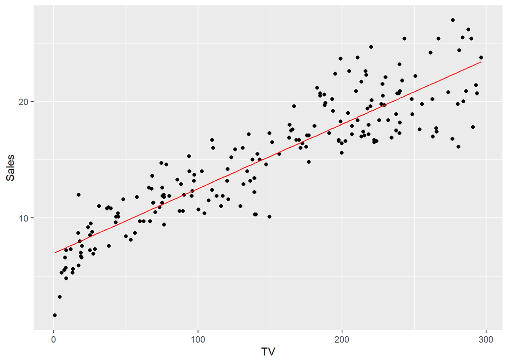

    ```r
    ggplot(augment(Sales_TV))+geom_point(aes(x=TV,y=Sales))+geom_line(aes(x=TV,y=.fitted),color="red")
    ```

- Fit a model for `Sales` using all predictors in the data set. Compare it to the model with the least important predictor removed. Does removing a predictor reduce or increase the quality of the model? Why?

  **Solution:**

  ```r
  Sales_all=lm(Sales~.,data=advertising)
  tidy(Sales_all)
  ```

  | term | estimate | std.error | statistic | p.value |
  | --- | --- | --- | --- | --- |
  | (Intercept) | 4.6251240788 | 0.307501165 | 15.04099695 | 1.682677e-34 |
  | TV | 0.0544457803 | 0.001375188 | 39.59152448 | 1.892945e-95 |
  | Radio | 0.1070012282 | 0.008489563 | 12.60385655 | 4.602097e-27 |
  | Newspaper | 0.0003356579 | 0.005788056 | 0.05799148 | 9.538145e-01 |

  The least important variable is `Newspaper`. Let us remove it from the model:

  ```r
  Sales_RadioTV=lm(Sales~Radio+TV,data=advertising)
  tidy(Sales_RadioTV)
  ```

  | term | estimate | std.error | statistic | p.value |
  | --- | --- | --- | --- | --- |
  | (Intercept) | 4.63087946 | 0.290308085 | 15.95160 | 2.526447e-37 |
  | Radio | 0.10717457 | 0.007925809 | 13.52222 | 6.662856e-30 |
  | TV | 0.05444896 | 0.001370614 | 39.72598 | 5.427771e-96 |

  ```r
  glance(Sales_all)
  ```

  | r.squared | adj.r.squared | sigma | statistic | p.value | df | logLik | AIC | BIC | deviance | df.residual | nobs |
  | --- | --- | --- | --- | --- | --- | --- | --- | --- | --- | --- | --- |
  | 0.9025913 | 0.9011003 | 1.661695 | 605.3801 | 8.133735e-99 | 3 | -383.3351 | 776.6702 | 793.1618 | 541.2012 | 196 | 200 |

  ```r
  glance(Sales_RadioTV)
  ```

  | r.squared | adj.r.squared | sigma | statistic | p.value | df | logLik | AIC | BIC | deviance | df.residual | nobs |
  | --- | --- | --- | --- | --- | --- | --- | --- | --- | --- | --- | --- |
  | 0.9025896 | 0.9016007 | 1.657487 | 912.6859 | 2.385704e-100 | 2 | -383.3368 | 774.6736 | 787.8669 | 541.2105 | 197 | 200 |

  Adjusted $R^2$ is slightly larger for the last model, so we may say that it is quite likely that the second model performs better with new data.

## Fitting a linear models by tidymodels framework

If we want to fit a linear model once for a concrete data set, then using `lm` command directly is probably the best option. Often we need to do the same thing repeatedly for model selection computations and in such cases it is better to use `tidymodels` framework, which unifies procedures for selecting, tuning and applying different models.

According to `tidymodels`f framework we should define a recipe for data preprocessing (if no preprocessing takes place, then recipe just declares input and output variables), a model specification (which type of model we want to fit and which command we want to use for that purpose) and put those things together in a workflow. After that, we can fit the model, perform model tuning operations, compute various performance statistics and so on in a unified way. We are going to learn about different aspects of using this workflow during the course, but for current lab it is important to know that we can for a simple data preprocessor by `rec=recipe(outcome_var~input_var1+...+imput_varm,data=dataset)`, we can specify that we want to use standard linear regression by `model_spec=linear_reg()` and that corresponding workflow is formed by `wf=workflow()%>%add_model(model_spec)%>%add_recipe(rec)`. The model can be fitted by `fitted_workflow=wf%>%fit(data=training_data)`, information can be obtained by `tidy` and `glance`, predictions can be obtained by `predict` command and `augment` allows one to add predictions to data. If we want to see more information about the fitted linear model, we can also extract the linear model fit by `extract_fit_engine(fitted_workflow)` and apply `augment` command to the linear model directly.

- **Exercise 2**: Use tidymodels framework to fit a linear model for `Sales` in terms of `Radio` for the advertising data set. Compute prediction in the case when 20000 dollars is spent on radio advertising.

**Solution:**

```r
rec=recipe(Sales~Radio,data=advertising)
m1=linear_reg()
wf1=workflow()%>%add_model(m1)%>%add_recipe(rec)
wf1_fitted=wf1%>%fit(advertising)
tidy(wf1_fitted)
```

| term | estimate | std.error | statistic | p.value |
| --- | --- | --- | --- | --- |
| (Intercept) | 12.2357220 | 0.65348629 | 18.72376 | 1.081986e-45 |
| Radio | 0.1244317 | 0.02369603 | 5.25116 | 3.882892e-07 |

```r
glance(wf1_fitted)
```

| r.squared | adj.r.squared | sigma | statistic | p.value | df | logLik | AIC | BIC | deviance | df.residual | nobs |
| --- | --- | --- | --- | --- | --- | --- | --- | --- | --- | --- | --- |
| 0.1222419 | 0.1178088 | 4.962898 | 27.57468 | 3.882892e-07 | 1 | -603.1806 | 1212.361 | 1222.256 | 4876.81 | 198 | 200 |

```r
predict(wf1_fitted,new_data = tibble(Radio=20))
```

| .pred |
| --- |
| 14.72436 |

## Detecting problems with model and/or data

Actually before starting to use a model for predictions and interpretation, one should make sure that there are no data errors which influence strongly the model, that the model is not biased and that the most important assumptions of linear models are satisfied. For this one can use several diagnostic plots.

- *Fitted values vs residuals* (prediction errors). In ideal case the residuals should behave like random errors with the same variance for all levels of predicted values.
  - Bias means that we may have mostly positive errors for some predicted values (for example, for small predicted values or for large values of a predictor) and mostly positive errors for some other region of predicted values or predictor values. This means that we should add some computed terms to our model (or transform some predictors and/or the response). In the case of bias we can not trust statistics in the output since fitted model is quite different from the “true model”.
  - *Heteroscedasticity* means that the size of the residuals change with the predicted value. This also makes statistical information about coefficients invalid. Often can be corrected by using logarithmic (or more general Box-Cox) transformation of the response variable or by adding relevant variables to the model.
- *Predictors vs residuals*. Help to detect prediction bias for some values of given predictor. Can be corrected by adding suitable computed variables.
- *quantile-quantile plot* with respect to normal distribution. Measures of fit which use likelihood of observations are computed under assumption of normal distribution and may be invalid when actual distribution of residuals is quite different from the normal distribution. Additionally important in the case of small data sets
- *Plot of standardized residuals vs leverage*. Residuals give information about outliers (suspicious values of the response variable). Leverage is a measure of how much a change in particular $y$ value at given $\mathbf{x}$ influences predicted vale $\hat{y}$ (depends only on how different the current $\mathbf{x}$ is from the average $\mathbf{x}$ value and on the number of observations). High leverage indicates data points which may potentially have large influence on the fitted model. Combination of large (in absolute value) residual and large leverage indicates a point which influences model quite strongly. Cook’s distance measures how much predictions change when a given point is removed from the data set and practical recommendation is that points with Cook’s distance higher than 1 should be very carefully checked.
- **Exercise 3**
  - Consider the model `Sales~TV+Radio` for the advertising data set. Can we consider the model adequate? Are there suspicious records in the data set which may influence the model strongly?

    **Solution:** Look at residuals vs fitted plot:

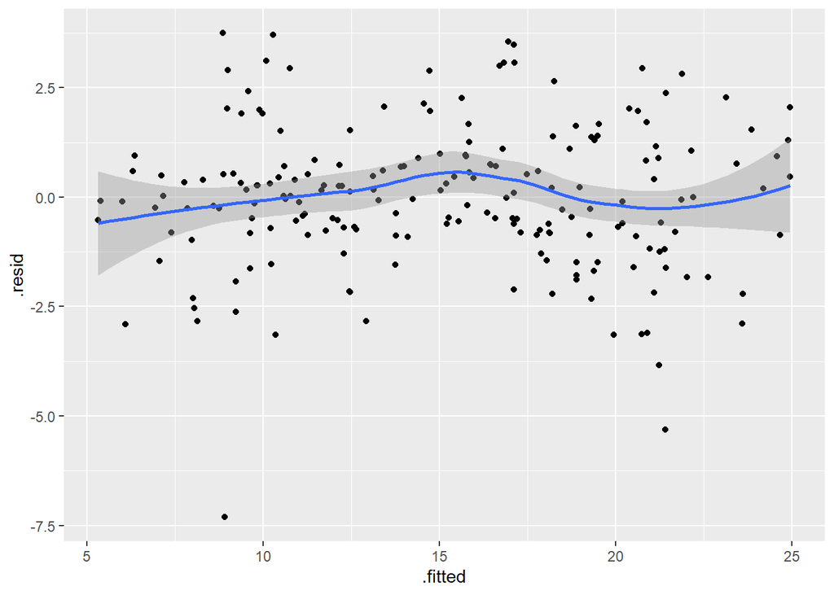

    ```r
    #can also use plot(Sales_RadioTV) or ggfortify::autoplot(Sales_RadioTV) to see main plots
    baseplot=ggplot(augment(Sales_RadioTV))
    #using geom_smooth to add a curve with observed info about average value around given fitted value
    baseplot+geom_point(aes(x=.fitted,y=.resid))+geom_smooth(aes(x=.fitted,y=.resid))
    ```

    Based on this graph, there is no clear evidence of bias (as the average of observed values is quite close to 0 everywhere) and no clear changes in the variance are visible.

    Graphs of residuals vs predictors:

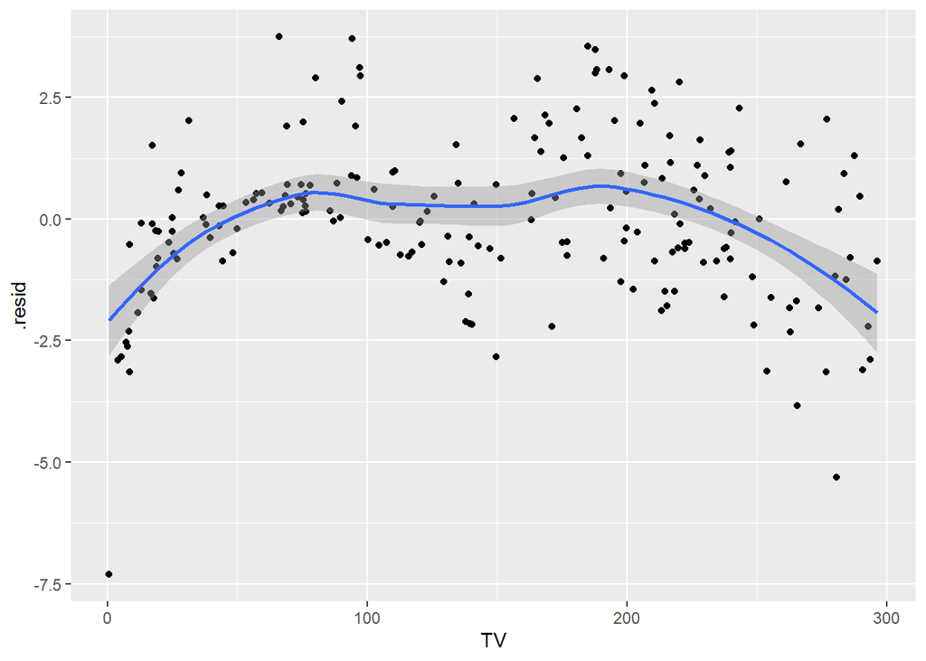

    ```r
    baseplot+geom_point(aes(x=TV,y=.resid))+geom_smooth(aes(x=TV,y=.resid))
    ```

    There seems to be some slight evidence of nonlinearity with respect to `TV` variable, so we may try to improve model with some interactions or function of `TV` advertising budget before fitting the linear model.

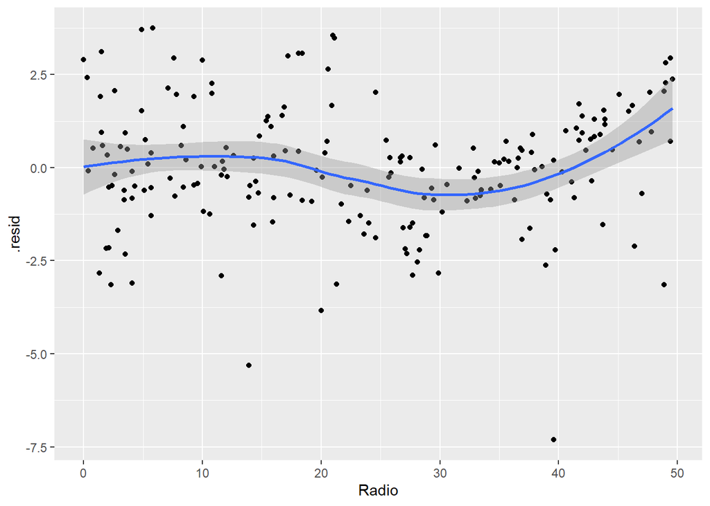

    ```r
    baseplot+geom_point(aes(x=Radio,y=.resid))+geom_smooth(aes(x=Radio,y=.resid))
    ```

    There also seems to be some weak nonlinearity with respect to `Radio` variable. We’ll consider a way of correcting problems when we’ll learn about generalised additive models. Since the nonlinear effects are not large compared to average size of residuals, the statistics related to the importance of variables and usefullness of the model should be quite OK.

It is also possible to look for possible biases with respect to several variables at the same time by forming a two-dimensional plot for values of those variables together with error information (encoded by color, for example). This way is may be possible to discover a need for interaction terms.

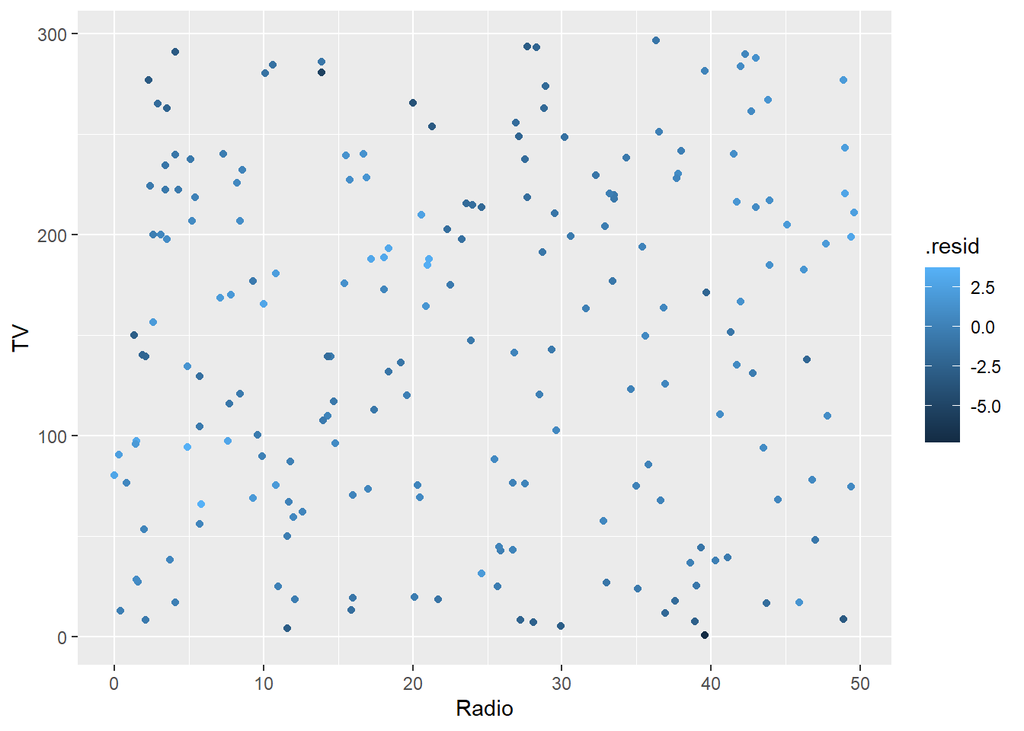

```r
baseplot+geom_point(aes(x=Radio,y=TV,color=.resid))
```

Based on this picture it seems that there are larger errors when both Radio and TV budgets are large but the need of adding interaction becomes clearer when nonlinear effects of TV and Radio separately are removed first.

QQ-plot:

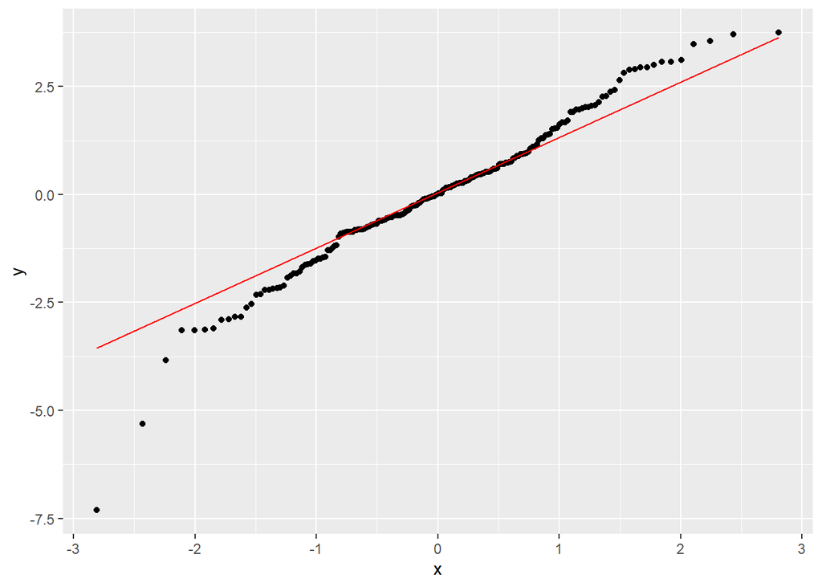

```r
    baseplot+geom_qq(aes(sample=.resid))+geom_qq_line(aes(sample=.resid),color="red")
```

Based on this this picture, there are more large (both negative and positive) residuals in our data than it is reasonable to expect in the case of normally distributed data. So quantities computed by assuming normality of residuals may not be valid (like AIC, BIC, likelihood)

*Standardized residuals vs leverage* Leverage is in the column `.hat` in augmented data frame

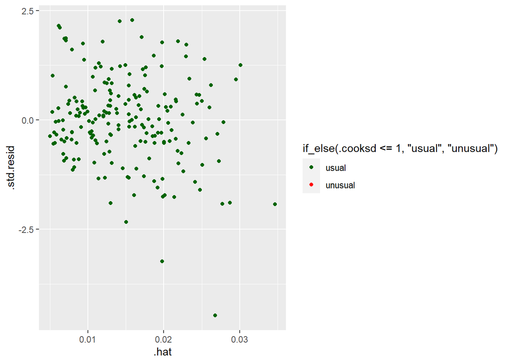

```r
    baseplot+geom_point(aes(x=.hat,y=.std.resid,color=if_else(.cooksd<=1,"usual","unusual")))+scale_color_manual(values=c("usual"="darkgreen","unusual"="red"))
```

We see that there is one observation for which the residual is quite large and negative (we may check corresponding observation for errors in response variable) and one observation, which is quite unusual in values of predictors (leverage is largest). Since no observation has Cook’s distance larger than 1, we can say that even if it turns out that there is a mistake in an observation, this does not influence significantly the usefulness of the model.

- Read in `Auto.csv` from the first lab. Fit a model `mpg ~ weight` to the data. Are the assumptions of using p-values and significance information in the output of fitted linear model valid?

  *Solution:* Fit the model and check residual vs fitted values plot

  ```r
  Auto=read_delim("Auto.csv",delim=",")
  ```

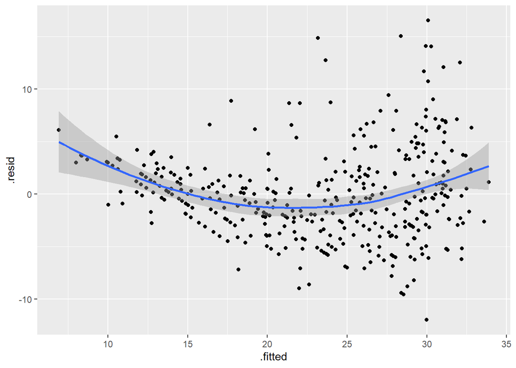

  ```r
  mpg_weight=lm(mpg ~ weight, data=Auto)
  ggplot(augment(mpg_weight))+geom_point(aes(x=.fitted,y=.resid))+geom_smooth(aes(x=.fitted,y=.resid))
  ```

  The model is slightly biased and definitely heteroscedastic (size of errors increase when predicted values increase). So assumptions for computing statistical information about the fit are not valid and we can not trust p-values given by model.
- In order to add computed variables to our models, we may either add them to data frame before modeling or we can indicate computations inside formula. Use a recipe to add a variable inv_weight to the data and fit a model for `mpg` in terms of `1/weight` to Auto data set (hint - you can remove weight variable in recipe by `step_rm` command). Is the fit better than before?

  **Solution:** Let us fit the model and look at residual plot again.

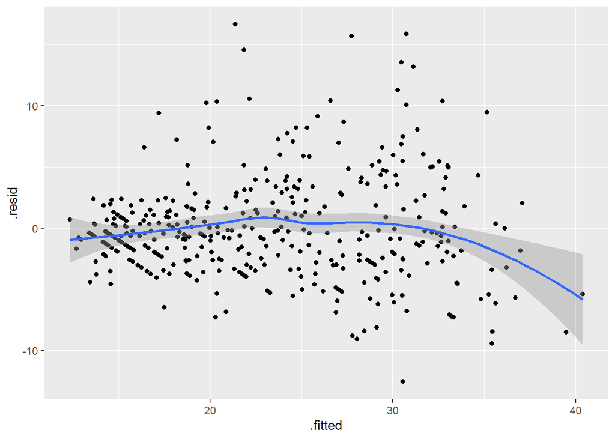

  ```r
  rec_invweight=recipe(mpg~weight,data=Auto) |> step_mutate(inv_weight=1/weight) |> step_rm(weight)
  wf_invweight=workflow()|>add_recipe(rec_invweight)|> add_model(linear_reg())
  mpg_invweight=wf_invweight |> fit(data=Auto)
  ggplot(augment(extract_fit_engine(mpg_invweight)))+geom_point(aes(x=.fitted,y=.resid))+geom_smooth(aes(x=.fitted,y=.resid))
  ```

  Although there is some heteroscedacity still visible (errors for very small fited values seem to have smaller variance) and there may be some bias in the case of large values, the assumptions of fitting linear model are not strongly violated and the statistical information about the model may be trusted (at least by this diagnostic picture) We can compare the models by $R^2$ statistic (since this does not depend on assumptions being valid):

  ```r
  glance(mpg_weight)%>%bind_rows(glance(mpg_invweight))
  ```

  | r.squared | adj.r.squared | sigma | statistic | p.value | df | logLik | AIC | BIC | deviance | df.residual | nobs |
  | --- | --- | --- | --- | --- | --- | --- | --- | --- | --- | --- | --- |
  | 0.6926304 | 0.6918423 | 4.332712 | 878.8309 | 6.015296e-102 | 1 | -1129.969 | 2265.939 | 2277.852 | 7321.234 | 390 | 392 |
  | 0.7067453 | 0.7059933 | 4.232061 | 939.9018 | 6.220397e-106 | 1 | -1120.755 | 2247.511 | 2259.425 | 6985.032 | 390 | 392 |

  The second model describes large fraction of variance of the response variable, so it can be considered to be better.

## Working with nominal/factor variables, adding interactions

Factor variables are nominal variables which are encoded by numbers. For example, we may have variable `sex` in our data set with values `Female` and `Male` and it becomes a factor variable if we encode the values by 0 and 1 (but also storing information about meaning of those numbers). Function `lm` works correctly with factor variables and also with textual variables (which it transforms to factors).

In case of fitting a model with a factor variable as predictor, actually for each level of the factor variable except one a new variable with values 0 and 1 is created and then usual linear model is fitted.

Interactions allow adding nonlinear effects to the model by considering products of variables. If we want to add to a model in addition to variables `x` and `y` the product `x*y` then we can indicate it in the model formula with `response ~ x*y`, so in case of product in model formula linear terms are automatically added. If we just want to add the product `X*Y` without linear terms, we can use `I()` or we can indicate it in the model formula with special operator `:` like `response ~ x:y`.

- **Exercise 4** Let us use data set `iris` which is included in R default datasets.
  - fit a linear model for `Sepal.Length` in terms of `Petal.Length` and the name of species

    **Solution:**

    ```r
    rec4=recipe(Sepal.Length~Petal.Length+Species, data=iris)
    mod4=linear_reg()
    wf4=workflow()|>add_model(mod4)|>add_recipe(rec4)
    wf4_fitted=fit(wf4,iris)
    tidy(wf4_fitted)
    ```

    | term | estimate | std.error | statistic | p.value |
    | --- | --- | --- | --- | --- |
    | (Intercept) | 3.6835266 | 0.10609608 | 34.718780 | 1.968671e-72 |
    | Petal.Length | 0.9045646 | 0.06478559 | 13.962436 | 1.121002e-28 |
    | Speciesversicolor | -1.6009717 | 0.19346616 | -8.275203 | 7.371529e-14 |
    | Speciesvirginica | -2.1176692 | 0.27346121 | -7.743947 | 1.480296e-12 |

    ```r
    glance(wf4_fitted)
    ```

    | r.squared | adj.r.squared | sigma | statistic | p.value | df | logLik | AIC | BIC | deviance | df.residual | nobs |
    | --- | --- | --- | --- | --- | --- | --- | --- | --- | --- | --- | --- |
    | 0.8367238 | 0.8333688 | 0.3380206 | 249.3968 | 3.101512e-57 | 3 | -48.11637 | 106.2327 | 121.2859 | 16.68166 | 146 | 150 |

    We see that two variables `Speciesversicolor` and `Speciesvirginica` were added to the model (they are 1, if Species is equal to value indicated in the name and 0 otherwise) and thus we got a model with different intercept for each species (the terms with Petal.Length are the same for each species, but the value of intercept is changed by -1.6010 for versicolor and by -2.11767 for virginica, compared to the intercept of setosa)
  - Compare the previous model to the model which contains also interactions of the two predictors used in the previous model. Which one would you use for predictions?

    **Solution:**

    ```r
    rec4b=rec4|>step_dummy(Species)|>step_interact(terms=~starts_with("Species"):Petal.Length)
    wf4b=workflow()|>add_model(mod4)|>add_recipe(rec4b)
    wf4b_fitted=fit(wf4b,iris)
    tidy(wf4b_fitted)
    ```

    | term | estimate | std.error | statistic | p.value |
    | --- | --- | --- | --- | --- |
    | (Intercept) | 4.2131682 | 0.4074209 | 10.341071 | 4.331619e-19 |
    | Petal.Length | 0.5422926 | 0.2767667 | 1.959385 | 5.199902e-02 |
    | Species_versicolor | -1.8056451 | 0.5984284 | -3.017312 | 3.016413e-03 |
    | Species_virginica | -3.1535091 | 0.6340741 | -4.973408 | 1.846894e-06 |
    | Species_versicolor_x_Petal.Length | 0.2859884 | 0.2950624 | 0.969247 | 3.340471e-01 |
    | Species_virginica_x_Petal.Length | 0.4534460 | 0.2901455 | 1.562823 | 1.202893e-01 |

    ```r
    glance(wf4b_fitted)
    ```

    | r.squared | adj.r.squared | sigma | statistic | p.value | df | logLik | AIC | BIC | deviance | df.residual | nobs |
    | --- | --- | --- | --- | --- | --- | --- | --- | --- | --- | --- | --- |
    | 0.8404527 | 0.8349129 | 0.3364509 | 151.7107 | 1.479356e-55 | 5 | -46.38365 | 106.7673 | 127.8418 | 16.30068 | 144 | 150 |

    In this case we have coefficient of Petal.Length also different for each species, so in fact we have fitted three separate models (one for each species). The interaction terms have relatively large p-values (definitely larger than 0.05), so we have statistically insignificant terms in our model. If our aim is making predictions, then our decision depends on which metric we decide to base it on. If we decide to use adjusted $R^2$, then the model with interactions is slightly better, but if we make decisions based on AIC or BIC, we should use the model without interactions.